```python
# I use a box at the beggining of my code to keep track to changes I make to the data set.
# Please reference as neessary.

# data1 is a copy of data to prevent changes to the original.
# data_obj is a subset of data1 that includes only columns of the obj data type.
# data_num is a subset of data1 that includes only columns with numerical data types.
# data2 is a copy of data1 without the case_id
```

# EasyVisa Project

## Context:

Business communities in the United States are facing high demand for human resources, but one of the constant challenges is identifying and attracting the right talent, which is perhaps the most important element in remaining competitive. Companies in the United States look for hard-working, talented, and qualified individuals both locally as well as abroad.

The Immigration and Nationality Act (INA) of the US permits foreign workers to come to the United States to work on either a temporary or permanent basis. The act also protects US workers against adverse impacts on their wages or working conditions by ensuring US employers' compliance with statutory requirements when they hire foreign workers to fill workforce shortages. The immigration programs are administered by the Office of Foreign Labor Certification (OFLC).

OFLC processes job certification applications for employers seeking to bring foreign workers into the United States and grants certifications in those cases where employers can demonstrate that there are not sufficient US workers available to perform the work at wages that meet or exceed the wage paid for the occupation in the area of intended employment.

## Objective:

In FY 2016, the OFLC processed 775,979 employer applications for 1,699,957 positions for temporary and permanent labor certifications. This was a nine percent increase in the overall number of processed applications from the previous year. The process of reviewing every case is becoming a tedious task as the number of applicants is increasing every year.

The increasing number of applicants every year calls for a Machine Learning based solution that can help in shortlisting the candidates having higher chances of VISA approval. OFLC has hired your firm EasyVisa for data-driven solutions. You as a data scientist have to analyze the data provided and, with the help of a classification model:

- Facilitate the process of visa approvals.
- Recommend a suitable profile for the applicants for whom the visa should be certified or denied based on the drivers that significantly influence the case status.

## Data Description

The data contains the different attributes of the employee and the employer. The detailed data dictionary is given below.

- case_id: ID of each visa application
- continent: Information of continent the employee
- education_of_employee: Information of education of the employee
- has_job_experience: Does the employee have any job experience? Y= Yes; N = No
- requires_job_training: Does the employee require any job training? Y = Yes; N = No
- no_of_employees: Number of employees in the employer's company
- yr_of_estab: Year in which the employer's company was established
- region_of_employment: Information of foreign worker's intended region of employment in the US.
- prevailing_wage: Average wage paid to similarly employed workers in a specific occupation in the area of intended employment. The purpose of the prevailing wage is to ensure that the foreign worker is not underpaid compared to other workers offering the same or similar service in the same area of employment.
- unit_of_wage: Unit of prevailing wage. Values include Hourly, Weekly, Monthly, and Yearly.
- full_time_position: Is the position of work full-time? Y = Full Time Position; N = Part Time Position
- case_status: Flag indicating if the Visa was certified or denied

## Importing necessary libraries and data

```python
# importing needed libraries
import numpy as np
import pandas as pd
import seaborn as sns
import matplotlib.pyplot as plt

# the regressor stuff is commented out so I can un-comment it if I need it later
from sklearn import tree
from sklearn.tree import DecisionTreeClassifier
# from sklearn.tree import DecisionTreeRegressor
from sklearn import metrics
from sklearn.metrics import confusion_matrix, classification_report, accuracy_score, precision_score, recall_score, f1_score, roc_auc_score
from sklearn.model_selection import GridSearchCV, train_test_split
# from sklearn.linear_model import LogisticRegression
from sklearn.ensemble import BaggingClassifier, RandomForestClassifier, AdaBoostClassifier, GradientBoostingClassifier, StackingClassifier
# from sklearn.ensemble import StackingRegressor
from xgboost import XGBClassifier
# from xgboost import XGBRegressor

import warnings
warnings.filterwarnings('ignore')

# removes the limit for number of columns displayed
pd.set_option("display.max_columns", None)
# limit the number of rows displayed
pd.set_option("display.max_rows", 100)
```

**Note**: *After running the above cell, kindly restart the notebook kernel and run all cells sequentially from the start again.*

```python
# mount my google drive
from google.colab import drive
drive.mount('/content/drive')

# read the csv file to a data frame
data=pd.read_csv('/content/drive/MyDrive/Python Foundations - GreatLearning/EasyVisa.csv')

# prevent changes to original data set
data1=data.copy()
```

## Data Overview

- Observations
- Sanity checks

```python
# view the head of the data
data1.head()
```

|  | case_id | continent | education_of_employee | has_job_experience | requires_job_training | no_of_employees | yr_of_estab | region_of_employment | prevailing_wage | unit_of_wage | full_time_position | case_status |
| --- | --- | --- | --- | --- | --- | --- | --- | --- | --- | --- | --- | --- |
| 0 | EZYV01 | Asia | High School | N | N | 14513 | 2007 | West | 592.2029 | Hour | Y | Denied |
| 1 | EZYV02 | Asia | Master's | Y | N | 2412 | 2002 | Northeast | 83425.6500 | Year | Y | Certified |
| 2 | EZYV03 | Asia | Bachelor's | N | Y | 44444 | 2008 | West | 122996.8600 | Year | Y | Denied |
| 3 | EZYV04 | Asia | Bachelor's | N | N | 98 | 1897 | West | 83434.0300 | Year | Y | Denied |
| 4 | EZYV05 | Africa | Master's | Y | N | 1082 | 2005 | South | 149907.3900 | Year | Y | Certified |

```python
# look at the shape of the data
data1.shape
```

```
(25480, 12)
```

```python
# look at the data types using info
data1.info()
```

```
<class 'pandas.core.frame.DataFrame'>
RangeIndex: 25480 entries, 0 to 25479
Data columns (total 12 columns):
 #   Column                 Non-Null Count  Dtype
---  ------                 --------------  -----
 0   case_id                25480 non-null  object
 1   continent              25480 non-null  object
 2   education_of_employee  25480 non-null  object
 3   has_job_experience     25480 non-null  object
 4   requires_job_training  25480 non-null  object
 5   no_of_employees        25480 non-null  int64
 6   yr_of_estab            25480 non-null  int64
 7   region_of_employment   25480 non-null  object
 8   prevailing_wage        25480 non-null  float64
 9   unit_of_wage           25480 non-null  object
 10  full_time_position     25480 non-null  object
 11  case_status            25480 non-null  object
dtypes: float64(1), int64(2), object(9)
memory usage: 2.3+ MB
```

```python
# check for duplicates in the data set
data1.duplicated().sum()
```

```
0
```

```python
# check for null data
data1.isnull().sum()
```

|  | 0 |
| --- | --- |
| case_id | 0 |
| continent | 0 |
| education_of_employee | 0 |
| has_job_experience | 0 |
| requires_job_training | 0 |
| no_of_employees | 0 |
| yr_of_estab | 0 |
| region_of_employment | 0 |
| prevailing_wage | 0 |
| unit_of_wage | 0 |
| full_time_position | 0 |
| case_status | 0 |

**dtype:** int64

```python
# check that the object columns include expected entries
# create a subest of the data that only includes columns of the object data type
data_obj=data1.select_dtypes(include='object')

# create a loop that outputs the unique entries in each column of data_obj
for col in data_obj:
  print(data_obj[col].value_counts())
```

```
case_id
EZYV01       1
EZYV16995    1
EZYV16993    1
EZYV16992    1
EZYV16991    1
            ..
EZYV8492     1
EZYV8491     1
EZYV8490     1
EZYV8489     1
EZYV25480    1
Name: count, Length: 25480, dtype: int64
continent
Asia             16861
Europe            3732
North America     3292
South America      852
Africa             551
Oceania            192
Name: count, dtype: int64
education_of_employee
Bachelor's     10234
Master's        9634
High School     3420
Doctorate       2192
Name: count, dtype: int64
has_job_experience
Y    14802
N    10678
Name: count, dtype: int64
requires_job_training
N    22525
Y     2955
Name: count, dtype: int64
region_of_employment
Northeast    7195
South        7017
West         6586
Midwest      4307
Island        375
Name: count, dtype: int64
unit_of_wage
Year     22962
Hour      2157
Week       272
Month       89
Name: count, dtype: int64
full_time_position
Y    22773
N     2707
Name: count, dtype: int64
case_status
Certified    17018
Denied        8462
Name: count, dtype: int64
```

## Exploratory Data Analysis (EDA)

- EDA is an important part of any project involving data.
- It is important to investigate and understand the data better before building a model with it.
- A few questions have been mentioned below which will help you approach the analysis in the right manner and generate insights from the data.
- A thorough analysis of the data, in addition to the questions mentioned below, should be done.

### Univariate Analysis

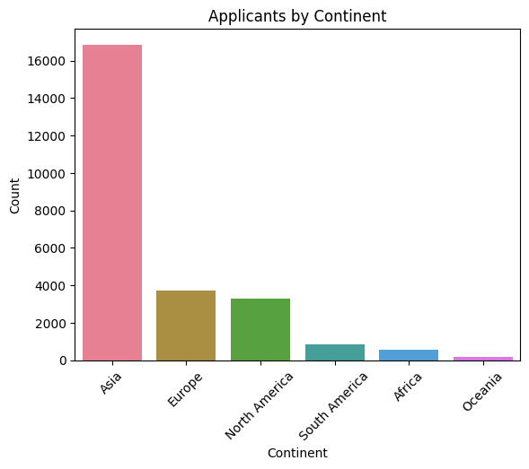

```python
# create a count plot for Continent
# count the occurrences of each continent and sort them
continent_counts = data1['continent'].value_counts()
sorted_continents = continent_counts.index

# create a color palette with different colors for each continent
palette = sns.color_palette('husl', len(sorted_continents))

# plot the bar plot with ordered x-axis and different colors
sns.countplot(x='continent', data=data1, order=sorted_continents, palette=palette)
plt.xlabel('Continent')
plt.ylabel('Count')
plt.title('Applicants by Continent')
plt.xticks(rotation=45)
plt.show()
```

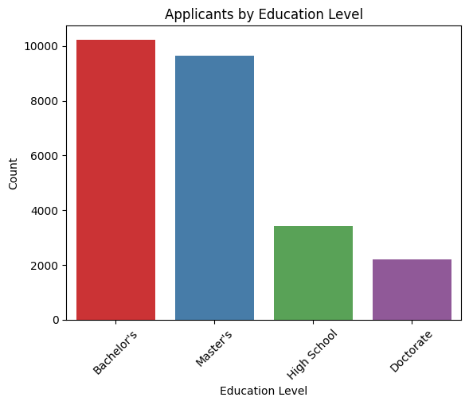

```python
# create a count plot for Education
# count the occurrences of each education level and sort them
education_counts = data1['education_of_employee'].value_counts()
sorted_education = education_counts.index

# create a color palette with different colors for each education level
palette = sns.color_palette('Set1', len(sorted_education))

# plot the bar plot with ordered x-axis and different colors
sns.countplot(x='education_of_employee', data=data1, order=sorted_education, palette=palette)
plt.xlabel('Education Level')
plt.ylabel('Count')
plt.title('Applicants by Education Level')
plt.xticks(rotation=45)
plt.show()
```

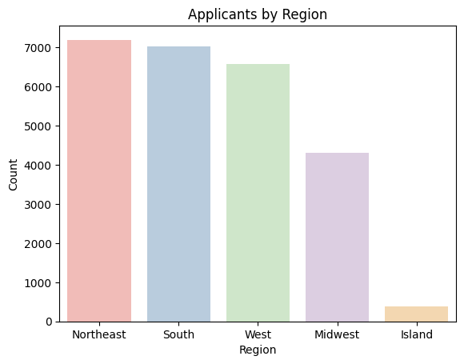

```python
# create a count plot for Region
# count the occurrences of each region and sort them
region_counts = data1['region_of_employment'].value_counts()
sorted_regions = region_counts.index

# create a color palette with different colors for each region
palette = sns.color_palette('Pastel1', len(sorted_regions))

# plot the bar plot with ordered x-axis and different colors
sns.countplot(x='region_of_employment', data=data1, order=sorted_regions, palette=palette)
plt.xlabel('Region')
plt.ylabel('Count')
plt.title('Applicants by Region')
plt.show()
```

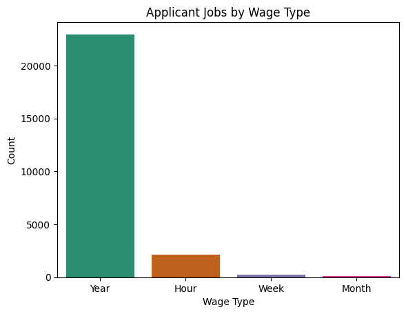

```python
# create a count plot for wage type
# count the occurances of each unit of wages and sort them
wages_counts = data1['unit_of_wage'].value_counts()
sorted_wages = wages_counts.index

# create a color palette with different colors for each wage type
palette = sns.color_palette('Dark2', len(sorted_wages))

# plot the bar plot with ordered x-axis and different colors
sns.countplot(x='unit_of_wage', data=data1, order=sorted_wages, palette=palette)
plt.xlabel('Wage Type')
plt.ylabel('Count')
plt.title('Applicant Jobs by Wage Type')
plt.show()
```

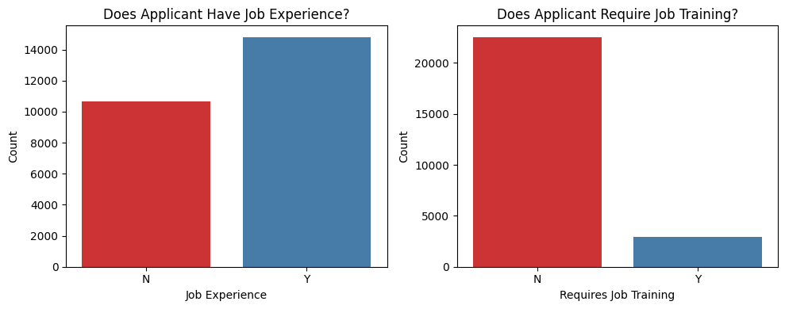

```python
# create a count plot of has_job_experience and requires_job_training
# create a 1x2 grid of subplots
fig, axes = plt.subplots(1, 2, figsize=(10, 4))

# create a color palette
palette = sns.color_palette('Set1')

# plot for 'has_job_experience'
sns.countplot(x='has_job_experience', data=data1, palette=palette, ax=axes[0])
axes[0].set_xlabel('Job Experience')
axes[0].set_ylabel('Count')
axes[0].set_title('Does Applicant Have Job Experience?')

# plot for 'requires_job_training'
sns.countplot(x='requires_job_training', data=data1, palette=palette, ax=axes[1])
axes[1].set_xlabel('Requires Job Training')
axes[1].set_ylabel('Count')
axes[1].set_title('Does Applicant Require Job Training?')

# adjust layout
plt.tight_layout()
plt.show()
```

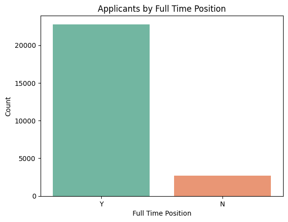

```python
# create a count plot for if the position is full time
palette = sns.color_palette('Set2')
sns.countplot(x='full_time_position', data=data1, palette=palette)
plt.xlabel('Full Time Position')
plt.ylabel('Count')
plt.title('Applicants by Full Time Position')
plt.show()
```

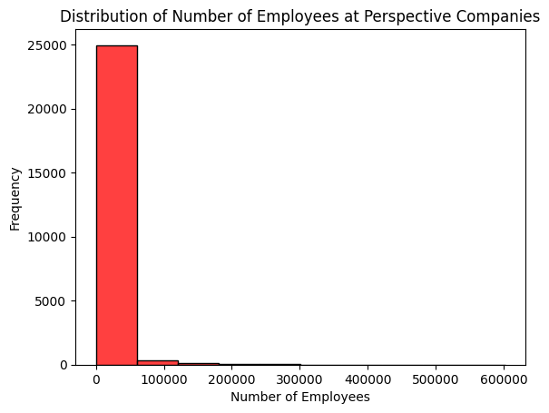

```python
# hisplot of no_of_employees for perspective employers' companies
sns.histplot(data=data1, x='no_of_employees', bins=10, kde=False, color="red")
plt.xlabel('Number of Employees')
plt.ylabel('Frequency')
plt.title('Distribution of Number of Employees at Perspective Companies')
plt.show()
```

The issue we run into here is that outliers are highly skewing the chart above.

Below, we will look at the companies below the 95th percentile to get a better idea of the distribution.

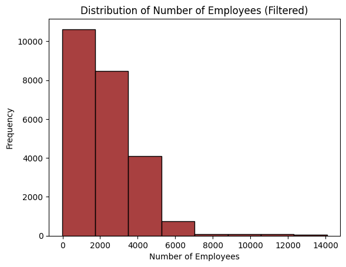

```python
# cap the maximum number of employees to a reasonable threshold
threshold = data1['no_of_employees'].quantile(0.95)  # set the threshold to 95th percentile
filtered_data = data1[data1['no_of_employees'] <= threshold]

# Plot histogram with filtered data
sns.histplot(data=filtered_data, x='no_of_employees', bins=8, kde=False, color="DarkRed")
plt.xlabel('Number of Employees')
plt.ylabel('Frequency')
plt.title('Distribution of Number of Employees (Filtered)')
plt.show()
```

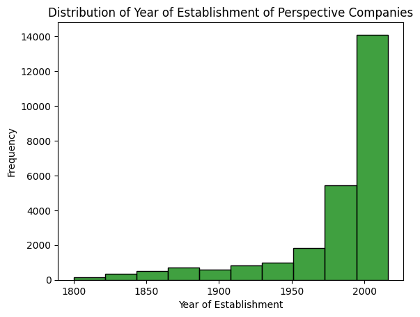

```python
#histplot of yr_of_estab of perspective employers' companies
sns.histplot(data=data1, x='yr_of_estab', bins=10, kde=False, color='Green')
plt.xlabel('Year of Establishment')
plt.ylabel('Frequency')
plt.title('Distribution of Year of Establishment of Perspective Companies')
plt.show()
```

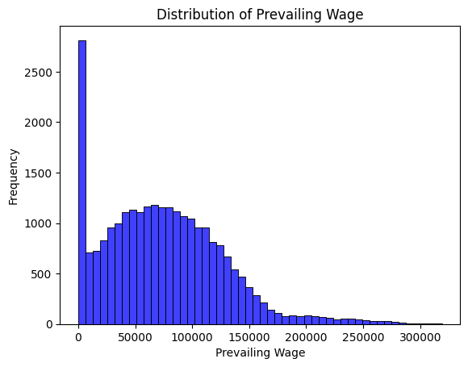

```python
# histplot of prevailing wage
sns.histplot(data=data1, x='prevailing_wage', bins=50, kde=False, color='Blue')
plt.xlabel('Prevailing Wage')
plt.ylabel('Frequency')
plt.title('Distribution of Prevailing Wage')
plt.show()
```

We can see above that since the data is a mix of hourly, weekly, monthly, and yearly pay, there are an extreme number of data points in the first bar of the histogram.

We can create a set of plots that gives the distribution of wages broken down by what type of pay it is (hourly, yearly, etc.)

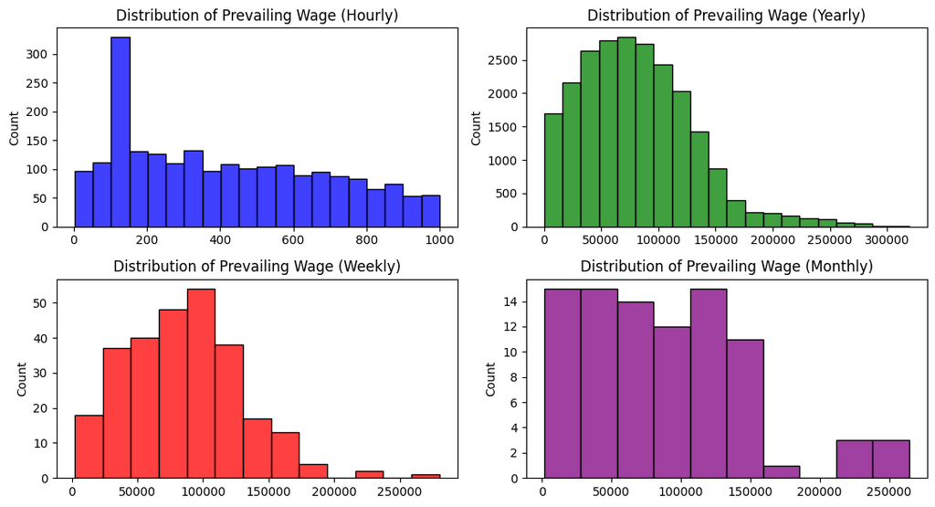

```python
# Define the unique units of wage
wage_units = data1['unit_of_wage'].unique()

# Create a 2x2 grid of subplots
fig, axes = plt.subplots(2, 2, figsize=(11, 6))

# Flatten the axes array for easier iteration
axes = axes.flatten()

# Define colors for the histograms
colors = ['blue', 'green', 'red', 'purple']

# Plot histograms for each unit of wage
for i, unit in enumerate(wage_units):
    ax = axes[i]
    subset = data1[data1['unit_of_wage'] == unit]

    # optimal number of bins for the current subset
    num_bins = min(20, max(10, int(len(subset) / 20)))

    sns.histplot(data=subset, x='prevailing_wage', bins=num_bins, kde=False, color=colors[i], ax=ax)

    ax.set_title(f'Distribution of Prevailing Wage ({unit}ly)')
    ax.set_xlabel('')
    ax.set_ylabel('Count')

# Adjust layout
plt.tight_layout()
plt.show()
```

If I were employed somewhere, working on this data set, I would ask about the hourly plot. Some jobs appear to be offering $900/hr but that seems implausible.

### Multivariate Analysis

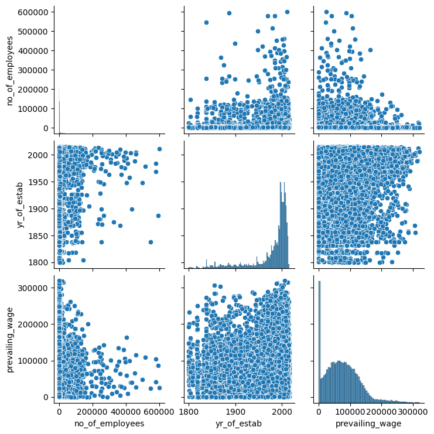

```python
# create a subset of the data that is only numerical data
data_num=data1.select_dtypes(include='number')

sns.pairplot(data_num)
plt.show()
```

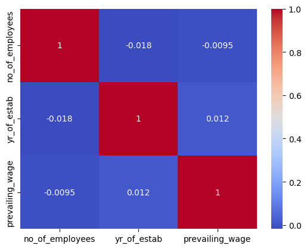

```python
# create a heatmap of the numerical data
sns.heatmap(data_num.corr(), annot=True, cmap='coolwarm')
plt.show()
```

### Leading Question Prompts

**Leading Questions**:

1. Those with higher education may want to travel abroad for a well-paid job. Does education play a role in Visa certification?
2. How does the visa status vary across different continents?
3. Experienced professionals might look abroad for opportunities to improve their lifestyles and career development. Does work experience influence visa status?
4. In the United States, employees are paid at different intervals. Which pay unit is most likely to be certified for a visa?
5. The US government has established a prevailing wage to protect local talent and foreign workers. How does the visa status change with the prevailing wage?

### Question 1

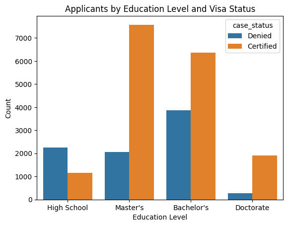

```python
# Question 1. Those with higher education may want to travel abroad for a well-paid job. Does education play a role in Visa certification?
# create a plot that shows applicants Visa acceptance or denial broken down by education
sns.countplot(x='education_of_employee', hue='case_status', data=data1)
plt.xlabel('Education Level')
plt.ylabel('Count')
plt.title('Applicants by Education Level and Visa Status')
plt.show()
```

This plot is great but I think the percentage breakdown would also be useful.

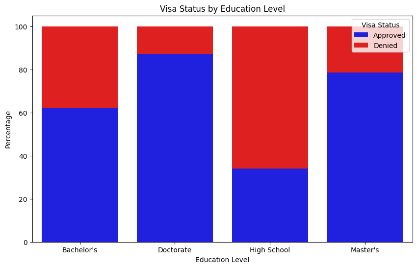

```python
# question 1. continued
# create a plot that shows what percentage of each education level had their Visa applications approved
education_counts = data1.groupby(['education_of_employee', 'case_status']).size().unstack()

# calculate percentages
percentages = education_counts.divide(education_counts.sum(axis=1), axis=0) * 100

# create a bar plot
plt.figure(figsize=(10, 6))
ax = sns.barplot(x=percentages.index, y=percentages['Certified'], color='blue', label='Approved', data=percentages)
sns.barplot(x=percentages.index, y=percentages['Denied'], color='red', label='Denied', data=percentages, bottom=percentages['Certified'])
plt.xlabel('Education Level')
plt.ylabel('Percentage')
plt.title('Visa Status by Education Level')
plt.legend(title='Visa Status')
plt.show()
```

Question 1 Answer:

We can clearly see from the plot above that applicants with a doctorate are most likely to be accepted at approx. 90%. The next highest rate of acceptance is applicants with their master's degree at approx. 80%. Applicants with bachelor's are accepted at a little over 60% and the lowest rate is by those applicants with only a high school education, only accepted at about 30%.

### Question 2

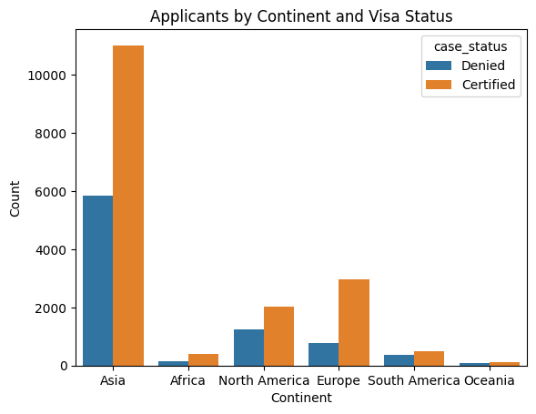

```python
# question 2. How does the visa status vary across different continents?
# create a plot that shows visa acceptance or denial broken down by continent
sns.countplot(x='continent', hue='case_status', data=data1)
plt.xlabel('Continent')
plt.ylabel('Count')
plt.title('Applicants by Continent and Visa Status')
plt.show()
```

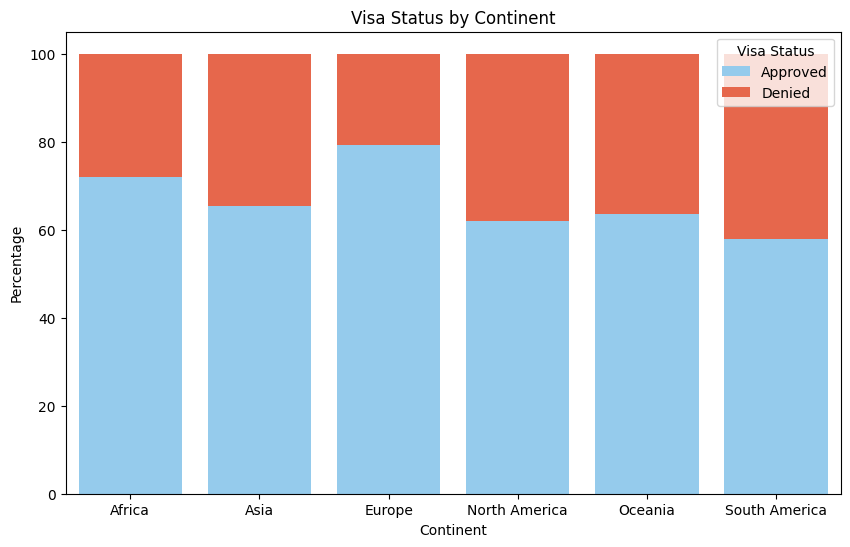

```python
# question 2. continued
# create a plot that shows what percentage of each applicant by continent had their Visa applications approved
continent_counts = data1.groupby(['continent', 'case_status']).size().unstack()

# calculate percentages
percentages = continent_counts.divide(continent_counts.sum(axis=1), axis=0) * 100

# create a bar plot
plt.figure(figsize=(10,6))
ax = sns.barplot(x=percentages.index, y=percentages['Certified'], color='#87CEFA', label='Approved', data=percentages)
sns.barplot(x=percentages.index, y=percentages['Denied'], color='#FF5733', label='Denied', data=percentages, bottom=percentages['Certified'])
plt.xlabel('Continent')
plt.ylabel('Percentage')
plt.title('Visa Status by Continent')
plt.legend(title='Visa Status')
plt.show()
```

### Question 3

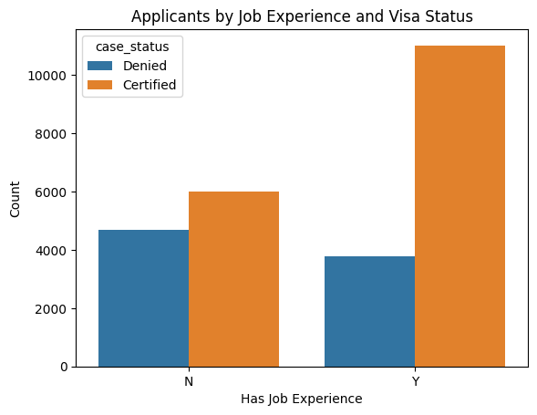

```python
# question 3. Does work experience influence visa status?
# create a plot of visa approval status broken down by if the applicant has job experience
sns.countplot(x='has_job_experience', hue='case_status', data=data1)
plt.xlabel('Has Job Experience')
plt.ylabel('Count')
plt.title('Applicants by Job Experience and Visa Status')
plt.show()
```

Question 3 Answer:

We can see there is a higher rate of visa certification for applicants that have job experience.

### Question 4

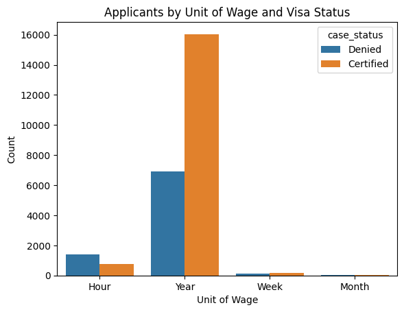

```python
# question 4. Which pay unit is most likely to be certified for a visa?
# create a plot of visa applicant approval or denial broken down by unit of wage
sns.countplot(x='unit_of_wage', hue='case_status', data=data1)
plt.xlabel('Unit of Wage')
plt.ylabel('Count')
plt.title('Applicants by Unit of Wage and Visa Status')
plt.show()
```

This is definitely useful but comparing each unit of wage to figure out which has the highest rate of approval is difficult when each unit of wage has vastly different application volume. Below we'll do another plot that compares percentages.

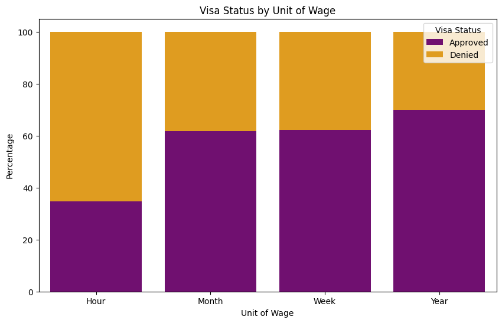

```python
# question 4 continued
# create a plot that shows what percentage of each applicant by unit of wage
wage_counts= data1.groupby(['unit_of_wage', 'case_status']).size().unstack()

# calculate percentages
percentages = wage_counts.divide(wage_counts.sum(axis=1), axis=0) * 100

# create a bar plot
plt.figure(figsize=(10,6))
ax = sns.barplot(x=percentages.index, y=percentages['Certified'], color='purple', label='Approved', data=percentages)
sns.barplot(x=percentages.index, y=percentages['Denied'], color='orange', label='Denied', data=percentages, bottom=percentages['Certified'])
plt.xlabel('Unit of Wage')
plt.ylabel('Percentage')
plt.title('Visa Status by Unit of Wage')
plt.legend(title='Visa Status')
plt.show()
```

Question 4 Answer:

Hourly positions are less likely to be approved by over 20% less than the next worst unit of wage while applying for yearly salaried positions gives the best chance of being approved.

### Question 5

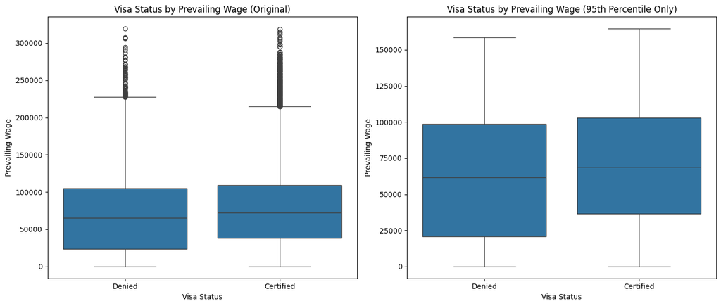

```python
# question 5. How does the visa status change with the prevailing wage?
# create two plots that shows visa approval status by prevailing wage and the 95% quantile of the data (to see without the outliers)
percentile_95 = data1.groupby('case_status')['prevailing_wage'].quantile(0.95)

# Filter data to exclude outliers beyond the 95th percentile
filtered_data = data1.copy()
filtered_data = filtered_data[filtered_data.apply(lambda row: row['prevailing_wage'] <= percentile_95[row['case_status']], axis=1)]

# Plotting the boxplots
fig, ax = plt.subplots(1, 2, figsize=(14, 6))

# Original boxplot
sns.boxplot(x='case_status', y='prevailing_wage', data=data1, ax=ax[0])
ax[0].set_xlabel('Visa Status')
ax[0].set_ylabel('Prevailing Wage')
ax[0].set_title('Visa Status by Prevailing Wage (Original)')

# Boxplot without outliers
sns.boxplot(x='case_status', y='prevailing_wage', data=filtered_data, ax=ax[1])
ax[1].set_xlabel('Visa Status')
ax[1].set_ylabel('Prevailing Wage')
ax[1].set_title('Visa Status by Prevailing Wage (95th Percentile Only)')

plt.tight_layout()
plt.show()
```

Question 5 Answer:

It seems that if an applicant is accepted, the associated wages are more likely to be slightly higher. This plot might not be very useful because we've already seen that higher education applicants and higher experience applicants are accepted at a higher rate, therefore it makes sense that the pool of applicants that are accepted have higher wages on average.

## Data Preprocessing

- Missing value treatment (if needed)
- Feature engineering
- Outlier detection and treatment (if needed)
- Preparing data for modeling
- Any other preprocessing steps (if needed)

```python
# Missing value treatement if needed
# check for missing values
data1.isnull().sum()
```

|  | 0 |
| --- | --- |
| case_id | 0 |
| continent | 0 |
| education_of_employee | 0 |
| has_job_experience | 0 |
| requires_job_training | 0 |
| no_of_employees | 0 |
| yr_of_estab | 0 |
| region_of_employment | 0 |
| prevailing_wage | 0 |
| unit_of_wage | 0 |
| full_time_position | 0 |
| case_status | 0 |

**dtype:** int64

No missing data treatment required because there are no null values.

```python
# Feature Engineering
# create a copy of the dataframe
data2=data1.copy()

# drop the ID column
data2.drop('case_id', axis=1, inplace=True)
```

The Case ID will not contribute to model building in any way.

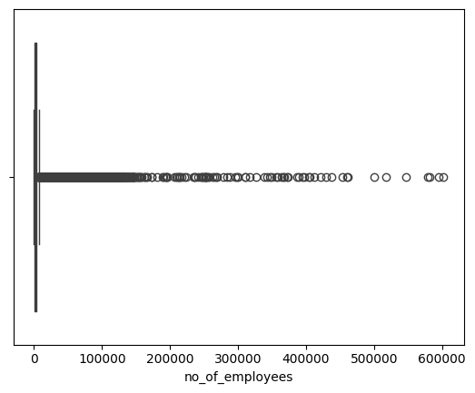

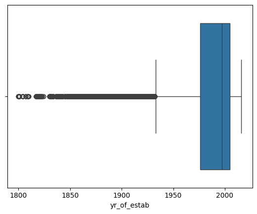

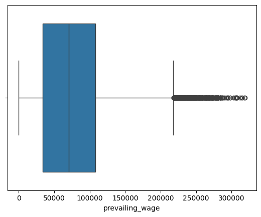

```python
# Outlier Detection
# check the numerical data for outliers
# create a for loop that creates a box plot for each column in data_num
for i in data_num:
  sns.boxplot(data=data1, x=i)
  plt.show()
```

There are multiple ways to show the outliers but it doesn't make much difference as these are all accurate values and therefore do not need to be fixed.

```python
# Preparing the data for modeling
# map job experience N to 0 and Y to 1
data2['has_job_experience']=data2['has_job_experience'].map({'N':0, 'Y':1})

# map requires job training N to 0 and Y to 1
data2['requires_job_training']=data2['requires_job_training'].map({'N':0, 'Y':1})

# map full time position N to 0 and Y to 1
data2['full_time_position']=data2['full_time_position'].map({'N':0, 'Y':1})

# map case status Certified to 1 and Denied to 0
data2['case_status']=data2['case_status'].map({'Certified':1, 'Denied':0})

# change the data type of job experience to data type int
data2['has_job_experience']=data2['has_job_experience'].astype(int)

# change the data type of requires job training to data type int
data2['requires_job_training']=data2['requires_job_training'].astype(int)

# change the data type of full time position to data type int
data2['full_time_position']=data2['full_time_position'].astype(int)

# change the data type of case status to data type int
data2['case_status']=data2['case_status'].astype(int)

# seperate data into dependent and independant using case_status as the dependent variable
X=data2.drop('case_status', axis=1)
y=data2['case_status']

# create dummy variables
X=pd.get_dummies(X, drop_first=True)

#split the data into train and test in a 70:30 ration and stratift
X_train, X_test, y_train, y_test = train_test_split(X, y, test_size=0.3, random_state=1, stratify=y)
```

## EDA

- It is a good idea to explore the data once again after manipulating it.

Not necesarry if none of the data was changed except for creating dummy variables and dropping a column that won't affect model outcome.

## Building bagging and boosting models

```python
def confusion_matrix_sklearn(model, predictors, target):
    """
    To plot the confusion_matrix with percentages

    model: classifier
    predictors: independent variables
    target: dependent variable
    """
    y_pred = model.predict(predictors)
    cm = confusion_matrix(target, y_pred)
    labels = np.asarray(
        [
            ["{0:0.0f}".format(item) + "\n{0:.2%}".format(item / cm.flatten().sum())]
            for item in cm.flatten()
        ]
    ).reshape(2, 2)

    plt.figure(figsize=(6, 4))
    sns.heatmap(cm, annot=labels, fmt="")
    plt.ylabel("True label")
    plt.xlabel("Predicted label")
```

```python
def model_performance_classification_sklearn(model, predictors, target):
    """
    Function to compute different metrics to check classification model performance

    model: classifier
    predictors: independent variables
    target: dependent variable
    """

    # predicting using the independent variables
    pred = model.predict(predictors)

    acc = accuracy_score(target, pred)  # to compute Accuracy
    recall = recall_score(target, pred)  # to compute Recall
    precision = precision_score(target, pred)  # to compute Precision
    f1 = f1_score(target, pred)  # to compute F1-score

    # creating a dataframe of metrics
    df_perf = pd.DataFrame(
        {
            "Accuracy": acc,
            "Recall": recall,
            "Precision": precision,
            "F1": f1,
        },
        index=[0],
    )

    return df_perf
```

```
Training performance:
    Accuracy    Recall  Precision        F1
0  0.759419  0.882901   0.784106  0.830576
Testing performance:
    Accuracy    Recall  Precision        F1
0  0.744767  0.873457   0.773595  0.820499
```

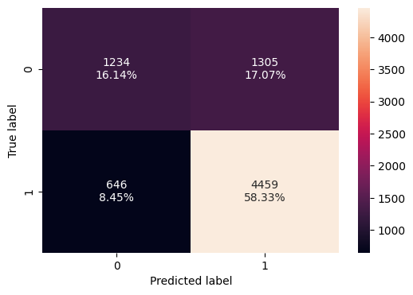

```python
# build a gradient boost model
gb = GradientBoostingClassifier(random_state=1)
gb.fit(X_train, y_train)

# create a confustion matrix
confusion_matrix_sklearn(gb, X_test, y_test)

# calculating different metrics
gb_model_train_perf = model_performance_classification_sklearn(gb, X_train, y_train)
print("Training performance:\n",gb_model_train_perf)
gb_model_test_perf = model_performance_classification_sklearn(gb, X_test, y_test)
print("Testing performance:\n",gb_model_test_perf)
```

```
Training performance:
    Accuracy    Recall  Precision        F1
0  0.738058  0.887434   0.760411  0.819027
Testing performance:
    Accuracy    Recall  Precision        F1
0  0.732993  0.885015    0.75653  0.815744
```

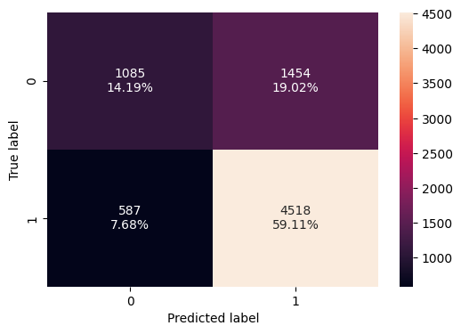

```python
# build an AdaBoost model
ada = AdaBoostClassifier(random_state=1)
ada.fit(X_train, y_train)

# create a confustion matrix
confusion_matrix_sklearn(ada, X_test, y_test)

# calculating different metrics
ada_model_train_perf = model_performance_classification_sklearn(ada, X_train, y_train)
print("Training performance:\n",ada_model_train_perf)
ada_model_test_perf = model_performance_classification_sklearn(ada, X_test, y_test)
print("Testing performance:\n",ada_model_test_perf)
```

```
Training performance:
    Accuracy    Recall  Precision        F1
0  0.985367  0.986066   0.991978  0.989013
Testing performance:
    Accuracy    Recall  Precision        F1
0  0.695709  0.767091   0.774985  0.771018
```

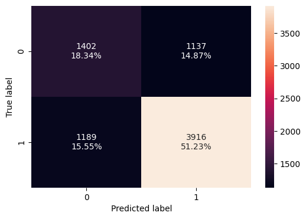

```python
# create a bagging classifier model
bag = BaggingClassifier(random_state=1)
bag.fit(X_train, y_train)

# create a confustion matrix
confusion_matrix_sklearn(bag, X_test, y_test)

# calculating different metrics
bag_model_train_perf = model_performance_classification_sklearn(bag, X_train, y_train)
print("Training performance:\n",bag_model_train_perf)
bag_model_test_perf = model_performance_classification_sklearn(bag, X_test, y_test)
print("Testing performance:\n",bag_model_test_perf)
```

```
Training performance:
    Accuracy  Recall  Precision   F1
0       1.0     1.0        1.0  1.0
Testing performance:
    Accuracy    Recall  Precision        F1
0  0.720304  0.831538   0.768604  0.798833
```

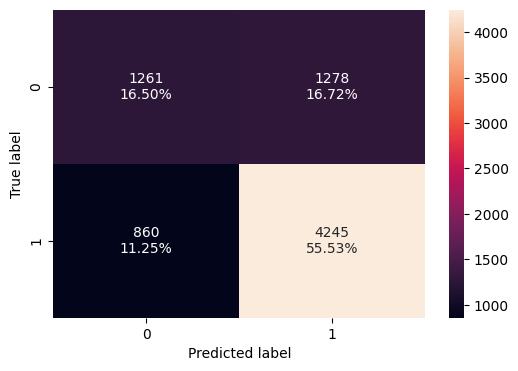

```python
# create a random forest classifier model
rf = RandomForestClassifier(random_state=1)
rf.fit(X_train, y_train)

# create a confustion matrix
confusion_matrix_sklearn(rf, X_test, y_test)

# calculating different metrics
rf_model_train_perf = model_performance_classification_sklearn(rf, X_train, y_train)
print("Training performance:\n",rf_model_train_perf)
rf_model_test_perf = model_performance_classification_sklearn(rf, X_test, y_test)
print("Testing performance:\n",rf_model_test_perf)
```

```
Training performance:
    Accuracy  Recall  Precision   F1
0       1.0     1.0        1.0  1.0
Testing performance:
    Accuracy    Recall  Precision        F1
0  0.661695  0.743389   0.748373  0.745873
```

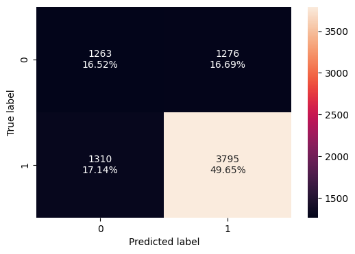

```python
# create a decision tree model
dtree= DecisionTreeClassifier(random_state=1)
dtree.fit(X_train, y_train)

# create a confustion matrix
confusion_matrix_sklearn(dtree, X_test, y_test)

# calculating different metrics
dtree_model_train_perf = model_performance_classification_sklearn(dtree, X_train, y_train)
print("Training performance:\n",dtree_model_train_perf)
dtree_model_test_perf = model_performance_classification_sklearn(dtree, X_test, y_test)
print("Testing performance:\n",dtree_model_test_perf)
```

```
Training performance:
    Accuracy    Recall  Precision        F1
0  0.843575  0.931084   0.849246  0.888284
Testing performance:
    Accuracy    Recall  Precision        F1
0  0.728545  0.855044   0.765789  0.807959
```

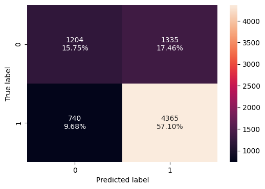

```python
# create XGBoost classifier model
XGB= XGBClassifier(random_state=1)
XGB.fit(X_train, y_train)

# create a confustion matrix
confusion_matrix_sklearn(XGB, X_test, y_test)

# calculating different metrics
XGB_model_train_perf = model_performance_classification_sklearn(XGB, X_train, y_train)
print("Training performance:\n",XGB_model_train_perf)
XGB_model_test_perf = model_performance_classification_sklearn(XGB, X_test, y_test)
print("Testing performance:\n",XGB_model_test_perf)
```

**Note**

1. Sample parameter grids have been provided to do necessary hyperparameter tuning. These sample grids are expected to provide a balance between model performance improvement and execution time. One can extend/reduce the parameter grid based on execution time and system configuration.
   - Please note that if the parameter grid is extended to improve the model performance further, the execution time will increase
- For Gradient Boosting:

```
param_grid = {
    "init": [AdaBoostClassifier(random_state=1),DecisionTreeClassifier(random_state=1)],
    "n_estimators": np.arange(50,110,25),
    "learning_rate": [0.01,0.1,0.05],
    "subsample":[0.7,0.9],
    "max_features":[0.5,0.7,1],
}
```

- For Adaboost:

```
param_grid = {
    "n_estimators": np.arange(50,110,25),
    "learning_rate": [0.01,0.1,0.05],
    "base_estimator": [
        DecisionTreeClassifier(max_depth=2, random_state=1),
        DecisionTreeClassifier(max_depth=3, random_state=1),
    ],
}
```

- For Bagging Classifier:

```
param_grid = {
    'max_samples': [0.8,0.9,1],
    'max_features': [0.7,0.8,0.9],
    'n_estimators' : [30,50,70],
}
```

- For Random Forest:

```
param_grid = {
    "n_estimators": [50,110,25],
    "min_samples_leaf": np.arange(1, 4),
    "max_features": [np.arange(0.3, 0.6, 0.1),'sqrt'],
    "max_samples": np.arange(0.4, 0.7, 0.1)
}
```

- For Decision Trees:

```
param_grid = {
    'max_depth': np.arange(2,6),
    'min_samples_leaf': [1, 4, 7],
    'max_leaf_nodes' : [10, 15],
    'min_impurity_decrease': [0.0001,0.001]
}
```

- For XGBoost:

```
param_grid={'n_estimators':np.arange(50,110,25),
            'scale_pos_weight':[1,2,5],
            'learning_rate':[0.01,0.1,0.05],
            'gamma':[1,3],
            'subsample':[0.7,0.9]
}
```